# R Notebook

`r`r library(tidyverse) library(outliers)

Load the code_clan_tweets.csv data. Find the number of rows, columns, and list all the variable names.

`r`r dim(cc_tweets)

```
[1] 234  27
```

`r`r names(cc_tweets)

```
 [1] \tweet_id\               \user_id\                \created_at\
 [4] \screen_name\            \text\                   \source\
 [7] \display_text_width\     \reply_to_status_id\     \reply_to_user_id\
[10] \reply_to_screen_name\   \is_quote\               \is_retweet\
[13] \favorite_count\         \retweet_count\          \quote_count\
[16] \reply_count\            \hashtags\               \symbols\
[19] \urls_url\               \urls_t.co\              \urls_expanded_url\
[22] \media_type\             \retweet_source\         \retweet_favorite_count\
[25] \retweet_retweet_count\  \retweet_user_id\        \retweet_location\
```

view(cc_tweets)

| tweet_id | user_id | created_at | screen_name | text | source | display_text_width | reply_to_status_id | reply_to_user_id | reply_to_screen_name | is_quote | is_retweet | favorite_count | retweet_count | quote_count | reply_count | hashtags | symbols | urls_url | urls_t.co | urls_expanded_url | media_type | retweet_source | retweet_favorite_count | retweet_retweet_count | retweet_user_id | retweet_location |
| --- | --- | --- | --- | --- | --- | --- | --- | --- | --- | --- | --- | --- | --- | --- | --- | --- | --- | --- | --- | --- | --- | --- | --- | --- | --- | --- |
| 347 | 3250721351 | 23/05/19 08:32 | CodeClanScot | @CodeClanScot has arrived in the Highlands! https://t.co/IJT6zbhEBT via @YouTube | Twitter Web App | 100 | NA | NA | NA | FALSE | TRUE | 0 | 1 | NA | NA | NA | NA | youtu.be/r3970XRMgeg | https://t.co/IJT6zbhEBT | https://youtu.be/r3970XRMgeg | NA | Twitter for iPhone | 5 | 1 | 1.110000e+18 | Edinburgh, Scotland |
| 346 | 3250721351 | 22/05/19 14:04 | CodeClanScot | We talked to one of our grads, Alex, about what it was like coming to CodeClan and changing career ___ Read her story here: https://t.co/UuFLgOFmcB | Twitter Web App | 148 | NA | NA | NA | FALSE | FALSE | 5 | 1 | NA | NA | NA | NA | bit.ly/2Hw8T1e | https://t.co/UuFLgOFmcB | https://bit.ly/2Hw8T1e | NA | NA | NA | NA | NA | NA |
| 345 | 3250721351 | 22/05/19 14:01 | CodeClanScot | A week to go until our #Dundee Sourcing the Next Generation of Talent event - have you booked your place yet? Come along to hear from @eplacementscot @GA_Dundee @CodeClanScot and @OUScotland on how th… | Twitter Web App | 140 | NA | NA | NA | FALSE | TRUE | 0 | 5 | NA | NA | Dundee | NA | NA | NA | NA | NA | Hootsuite Inc. | 6 | 5 | 3.997880e+07 | Scotland |
| 344 | 3250721351 | 22/05/19 13:22 | CodeClanScot | New #tech means new business opportunities. Join @IngledewStephen, @C_Leaver, @MaMChannel, @GerryMcCusker, @DonaldMcL, @pollyp + more at #DigitalScotland19 for some exciting chats around #skills &amp;… | Twitter Web App | 140 | NA | NA | NA | FALSE | TRUE | 0 | 4 | NA | NA | tech | NA | NA | NA | NA | NA | Twitter Web Client | 6 | 4 | 3.288078e+09 | Edinburgh, Scotland |
| 343 | 3250721351 | 22/05/19 10:10 | CodeClanScot | Scotland needs Data Analysts! Learn how you can gain the skills to transform your career at our Data Analysis Information Evening this Thursday. book your free ticket here: https://t.co/0UDZFQaGeB htt… | Twitter Web App | 196 | NA | NA | NA | FALSE | FALSE | 3 | 1 | NA | NA | NA | NA | bit.ly/2JUmdy0 | https://t.co/0UDZFQaGeB | http://bit.ly/2JUmdy0 | photo | NA | NA | NA | NA | NA |
| 342 | 3250721351 | 21/05/19 13:16 | CodeClanScot | RT @TechmumsHQ: Congrats to our Edinburgh #techmums on graduating and well done to the amazing @CodeClanScot facilitators for running such a brilliant #techmumsClub #digitalskillsmatter #empoweringwom… | Twitter Web App | 140 | NA | NA | NA | FALSE | TRUE | 0 | 3 | NA | NA | techmums | NA | NA | NA | NA | NA | IFTTT | 8 | 3 | 9.439170e+08 | Chicago, IL |

SOLUTION

```r
# 1 : do some initial data exploration
codeclan_tweets <- read_csv("data/code_clan_tweets.csv")
```

```r
view(codeclan_tweets)
dim(codeclan_tweets)
```

```
[1] 234  27
```

```r
names(codeclan_tweets)
```

[output not shown]

2. First, we’re going to summarise the number of likes (favorite_count) CodeClan tweets have. Create a boxplot to check for outliers.

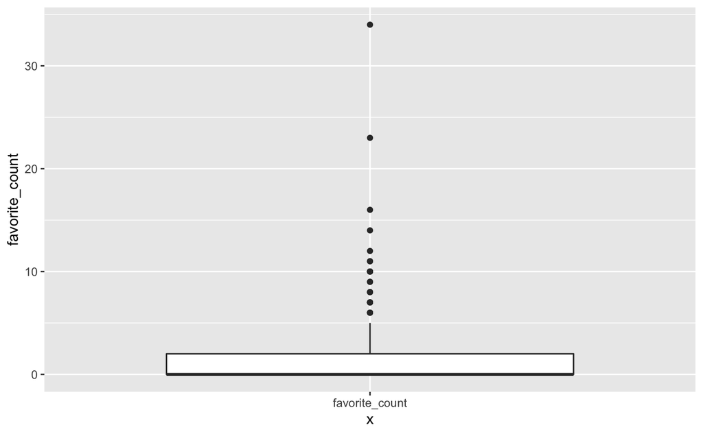

SOLUTION

```r
# 2 : use a box plot to see if we have outliers in the favourite_count column
ggplot(codeclan_tweets, aes(x = "favorite_count", favorite_count)) +
  geom_boxplot()
```

[output not shown]

3. Find the total number of favourited tweets (stored in favorite_count) that CodeClan tweets have got. Don’t add a tweet’s favorite_count to the total when the tweet was quoted (see the is_quote variable).

| total |
| --- |
| 425 |

SOLUTION

```r
# 3 : count total number of favourites
codeclan_tweets %>%
  filter(is_quote == FALSE) %>%
  summarise(total = sum(favorite_count))
```

| total |
| --- |
| 425 |

Summarise the mean number of retweets (retweet_count), split by the type of platform that was used to tweet (source). Again, omit quoted tweets from the mean.

`r`r summary(cc_tweets$retweet_count)

```
   Min. 1st Qu.  Median    Mean 3rd Qu.    Max.
  0.000   1.000   2.000   2.521   4.000  18.000
```

cc_tweets %>% group_by(retweet_count) %>% summarise(n = n(), average = mean(retweet_count))

| retweet_count | n | average |
| --- | --- | --- |
| 0 | 49 | 0 |
| 1 | 48 | 1 |
| 2 | 44 | 2 |
| 3 | 33 | 3 |
| 4 | 23 | 4 |
| 5 | 14 | 5 |
| 6 | 5 | 6 |
| 7 | 9 | 7 |
| 8 | 3 | 8 |
| 9 | 1 | 9 |

[output cut: 4 more lines]

| count |
| --- |
| 590 |

`r`r cc_tweets %>% filter(is_quote == FALSE) %>% group_by(source) %>% summarise(average_retweet = mean(retweet_count))

| source | average_retweet |
| --- | --- |
| Hootsuite Inc. | 1.428571 |
| Tweetbot for Mac | 4.000000 |
| TweetDeck | 5.000000 |
| Twitter for iPhone | 3.051948 |
| Twitter Web App | 2.478632 |
| Twitter Web Client | 2.000000 |

SOLUTION

```r
# 4 : summarise mean number of retweets by source platform
codeclan_tweets %>%
  filter(is_quote == FALSE) %>%
  group_by(source) %>%
  summarise(average_retweet = mean(retweet_count))
```

[output not shown]

5. Count the total number of likes (i.e. total of favorite_count), split by media type, and arrange them from most likes to least. Assume that any tweets without a listed media type are of type “text”.

[output not shown]

SOLUTION

```r
# 5 : count the number of likes by media type, and arrange them from most likes to least
codeclan_tweets %>%
  mutate(media_type2 = replace_na(media_type, "text")) %>%
  group_by(media_type2) %>%
  summarise(favourite_count_total = sum(favorite_count)) %>%
  arrange(desc(favourite_count_total))
```

[output not shown]

6. Find the mean number of characters that a CodeClan tweet contains.

| avg_tweet_length |
| --- |
| 149.4188 |

SOLUTION

```r
# 6 : find the mean number of characters a tweet contains
codeclan_tweets %>%
  summarise(avg_tweet_length = mean(display_text_width))
```

| avg_tweet_length |
| --- |
| 149.4188 |

7. The code_clan_info.csv data file contains status_url along with other info. Load this in, and join it to the code_clan_tweets tibble, so that you have a status_url for each tweet. Decide which variable to join the tibbles on.

SOLUTION

```r
# 7 : join where there is a tweet
codeclan_info <- read_csv("data/code_clan_info.csv")
```

```r
names(codeclan_info)
```

```
 [1] "tweet_id"           "status_url"         "name"               "location"
 [5] "description"        "url"                "protected"          "followers_count"
 [9] "friends_count"      "listed_count"       "statuses_count"     "favourites_count"
[13] "account_created_at" "verified"           "profile_url"
```

```r
codeclan_all <- left_join(codeclan_tweets,codeclan_info, by = "tweet_id")
```

8. From your new joined data, create a new tibble codeclan_hashtags containing only the tweet_id and hashtags in lowercase for analysis. Keep only those tweets with hashtags.

`r`r codeclan_hashtag <- codeclan_all %>% select(tweet_id, hashtags) %>% mutate(lowcase_hashtag = str_to_lower(hashtags)) %>% select(-hashtags) %>% drop_na(lowcase_hashtag)

| tweet_id | lowcase_hashtag |
| --- | --- |
| 345 | dundee |
| 344 | tech |
| 342 | techmums |
| 341 | techmums |
| 340 | techmums |
| 336 | techmums |
| 335 | forensicshoeprints |
| 332 | forensicshoeprints |
| 331 | forensicshoeprints |
| 329 | inverness |

[output cut: 107 more lines]

```r
# 8 : create a variable which has all the hashtags in lowercase for analysis
codeclan_hashtags <- codeclan_all%>%
  select(tweet_id, hashtags) %>%
  mutate(lowcase_hashtag = str_to_lower(hashtags)) %>%
  select(-hashtags) %>%
  drop_na(lowcase_hashtag)

codeclan_hashtags
```

[output not shown]

EXTENSIONS

9 .Use the str_sub function to get the first 2 letters of each tweet

```r
hashtags_multiple <- codeclan_hashtag %>%
  mutate(first_letters = str_sub(lowcase_hashtag, 1, 2)) %>%
  filter(str_detect(first_letters, "c\\("))

hashtags_multiple
```

[output not shown]

question 10: Use the str_detect() function to find all cases where a tweet text mentions edinburgh, and count in how many tweets it appears

| count |
| --- |
| 33 |

question 11: use str_extract_all and regex to find usernames

```
[[1]]
[1] \@CodeClanScot\ \@YouTube\

[[2]]
character(0)

[[3]]
[1] \@eplacementscot\ \@GA_Dundee\      \@CodeClanScot\   \@OUScotland\

[[4]]
[1] \@IngledewStephen\ \@C_Leaver\        \@MaMChannel\      \@GerryMcCusker\
[5] \@DonaldMcL\       \@pollyp\

[[5]]
character(0)

[[6]]
[1] \@TechmumsHQ\   \@CodeClanScot\
```